# E-commerce Analysis

**Ce projet analyse des données d'achat de E commerce, apres avoir nettoyé et rendu plus cohérent les données, nous avons sortis des visuels intéressants sur la tendance des ventes puis nous avons applquer un algorithme de K-means afin de déduire les diffférents types de clients**

```python
import numpy as np
import matplotlib.pyplot as plt
import pandas as pd
import warnings
warnings.filterwarnings("ignore")
```

```python
# Chargement du fichier CSV
ecommerce_data = pd.read_csv('data.csv', encoding='ISO-8859-1', parse_dates=['InvoiceDate'])

# Affichage des premières lignes
ecommerce_data_head = ecommerce_data.head()
ecommerce_data_head
```

|  | InvoiceNo | StockCode | Description | Quantity | InvoiceDate | UnitPrice | CustomerID | Country |
| --- | --- | --- | --- | --- | --- | --- | --- | --- |
| 0 | 536365 | 85123A | WHITE HANGING HEART T-LIGHT HOLDER | 6 | 2010-12-01 08:26:00 | 2.55 | 17850.0 | United Kingdom |
| 1 | 536365 | 71053 | WHITE METAL LANTERN | 6 | 2010-12-01 08:26:00 | 3.39 | 17850.0 | United Kingdom |
| 2 | 536365 | 84406B | CREAM CUPID HEARTS COAT HANGER | 8 | 2010-12-01 08:26:00 | 2.75 | 17850.0 | United Kingdom |
| 3 | 536365 | 84029G | KNITTED UNION FLAG HOT WATER BOTTLE | 6 | 2010-12-01 08:26:00 | 3.39 | 17850.0 | United Kingdom |
| 4 | 536365 | 84029E | RED WOOLLY HOTTIE WHITE HEART. | 6 | 2010-12-01 08:26:00 | 3.39 | 17850.0 | United Kingdom |

```python
#Nettoyage et prétraitement des données

# Suppression des entrées avec des valeurs manquantes
ecommerce_data_cleaned = ecommerce_data.dropna(subset=['Description', 'CustomerID'])

# Filtrage des entrées non pertinentes (annulations ou quantités négatives)
ecommerce_data_cleaned = ecommerce_data_cleaned[ecommerce_data_cleaned['Quantity'] > 0]
ecommerce_data_cleaned = ecommerce_data_cleaned[ecommerce_data_cleaned['CustomerID'] != 12346 ]

# Création d'une nouvelle colonne pour le total des ventes par transaction
ecommerce_data_cleaned['TotalSales'] = ecommerce_data_cleaned['Quantity'] * ecommerce_data_cleaned['UnitPrice']
ecommerce_data_cleaned = ecommerce_data_cleaned[ecommerce_data_cleaned['TotalSales'] != 0]


ecommerce_data_cleaned.shape
```

```
(397883, 9)
```

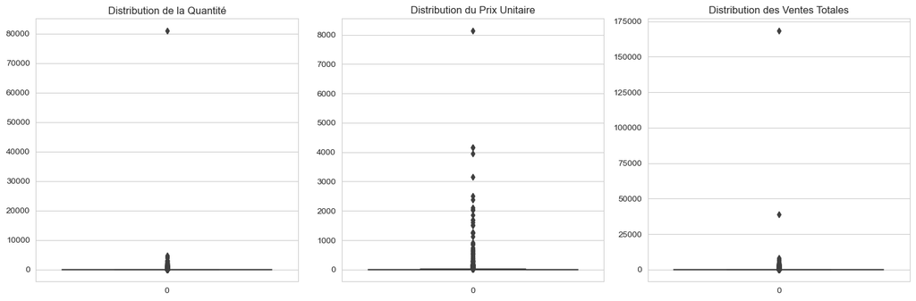

```python
import matplotlib.pyplot as plt
import seaborn as sns

# Configuration des visualisations
sns.set_style('whitegrid')
plt.figure(figsize=(15, 5))

# Distribution de la Quantité
plt.subplot(1, 3, 1)
sns.boxplot(ecommerce_data_cleaned['Quantity'])
plt.title('Distribution de la Quantité')

# Distribution du Prix Unitaire
plt.subplot(1, 3, 2)
sns.boxplot(ecommerce_data_cleaned['UnitPrice'])
plt.title('Distribution du Prix Unitaire')

# Distribution des Ventes Totales
plt.subplot(1, 3, 3)
sns.boxplot(ecommerce_data_cleaned['TotalSales'])
plt.title('Distribution des Ventes Totales')

plt.tight_layout()
plt.show()
```

```python
def remove_outliers_using_iqr(df, column):
    """
    On va retitrer les valeurs aberrantes en utilisant la méthode IQR
    """
    # Calcul IQR
    Q1 = df[column].quantile(0.25)
    Q3 = df[column].quantile(0.75)
    IQR = Q3 - Q1

    # Definition des limites
    lower_bound = Q1 - 0.5 * IQR
    upper_bound = Q3 + 0.5 * IQR

    # Filter the data
    return df[(df[column] >= lower_bound) & (df[column] <= upper_bound)]

# Remove outliers for Quantity and UnitPrice
data_cleaned = remove_outliers_using_iqr(ecommerce_data_cleaned, 'Quantity')
data_cleaned = remove_outliers_using_iqr(ecommerce_data_cleaned, 'UnitPrice')
data_cleaned = remove_outliers_using_iqr(ecommerce_data_cleaned, 'TotalSales')

data_cleaned.shape
```

```
(340548, 9)
```

```python
ecommerce_data_Ab = data_cleaned[data_cleaned['CustomerID'] == 12346]
ecommerce_data_Ab
```

|  | InvoiceNo | StockCode | Description | Quantity | InvoiceDate | UnitPrice | CustomerID | Country | TotalSales |
| --- | --- | --- | --- | --- | --- | --- | --- | --- | --- |

```python
data_cleaned.shape
```

```
(340548, 9)
```

```python
ecommerce_data_cleaned = data_cleaned
```

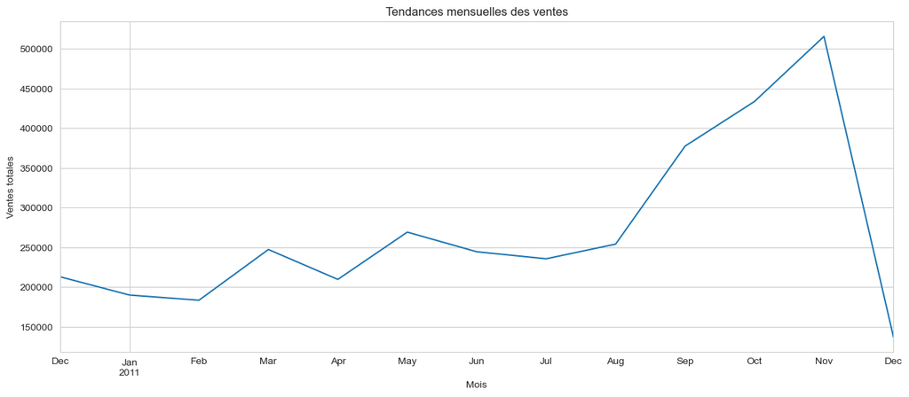

```python
# Extraction du mois et de l'année de la colonne 'InvoiceDate'
ecommerce_data_cleaned['YearMonth'] = ecommerce_data_cleaned['InvoiceDate'].dt.to_period('M')

# Agrégation des données pour obtenir les ventes totales par mois
monthly_sales = ecommerce_data_cleaned.groupby('YearMonth')['TotalSales'].sum()

# Visualisation des ventes mensuelles
plt.figure(figsize=(15, 6))
monthly_sales.plot()
plt.title('Tendances mensuelles des ventes')
plt.xlabel('Mois')
plt.ylabel('Ventes totales')
plt.grid(True)

plt.show()
```

La visualisation montre les tendances mensuelles des ventes pour la période couverte par le jeu de données.

Observations clés :

1. **Croissance générale** : Il y a une tendance à la hausse des ventes au fil du temps, avec quelques fluctuations.
2. **Pic à la fin de l'année** : Il y a un pic notable des ventes à la fin de l'année, probablement en novembre ou décembre, ce qui pourrait être lié aux achats des fêtes de fin d'année.
3. **Fluctuations mensuelles** : Outre le pic à la fin de l'année, d'autres mois montrent également des augmentations ou des baisses des ventes, ce qui pourrait être dû à divers facteurs promotionnels, saisonniers ou autres.

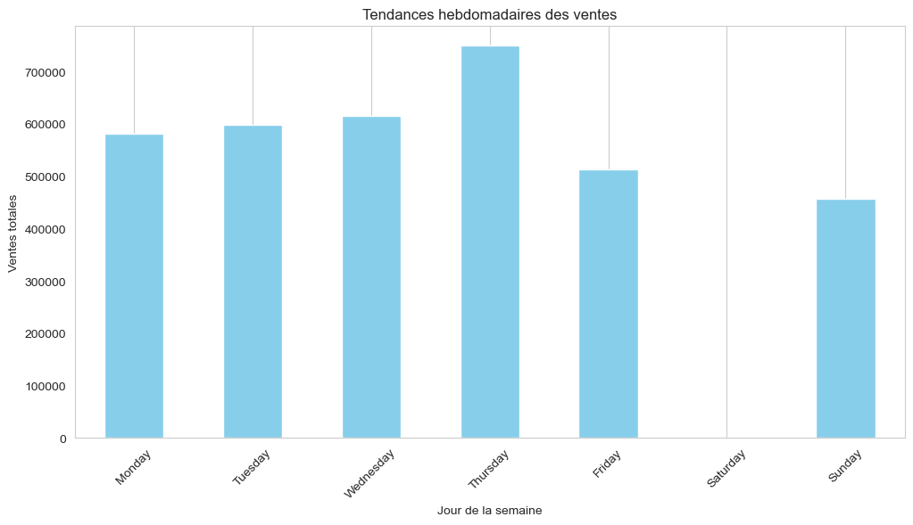

```python
# Extraction du jour de la semaine de la colonne 'InvoiceDate'
ecommerce_data_cleaned['Weekday'] = ecommerce_data_cleaned['InvoiceDate'].dt.day_name()

# Ordre des jours de la semaine pour la visualisation
order = ['Monday', 'Tuesday', 'Wednesday', 'Thursday', 'Friday', 'Saturday', 'Sunday']

# Agrégation des données pour obtenir les ventes totales par jour de la semaine
weekday_sales = ecommerce_data_cleaned.groupby('Weekday')['TotalSales'].sum().reindex(order)

# Visualisation des ventes hebdomadaires
plt.figure(figsize=(12, 6))
weekday_sales.plot(kind='bar', color='skyblue')
plt.title('Tendances hebdomadaires des ventes')
plt.xlabel('Jour de la semaine')
plt.ylabel('Ventes totales')
plt.xticks(rotation=45)
plt.grid(axis='y')
plt.show()
```

La visualisation montre les tendances des ventes en fonction du jour de la semaine.

Observations clés :

1. **Jours de semaine** : Les ventes sont nettement plus élevées les jours de semaine, avec un pic le jeudi.
2. **Weekend** : Il y a une baisse significative des ventes pendant le weekend, en particulier le samedi, où les ventes sont presque nulles. Il est possible que l'entreprise ne fonctionne pas ou ait une activité réduite le weekend.
3. **Jeudi** : Le jeudi semble être le jour le plus actif en termes de ventes.

Ces informations pourraient être utiles pour planifier des promotions, gérer les stocks ou allouer des ressources en fonction des jours de la semaine.

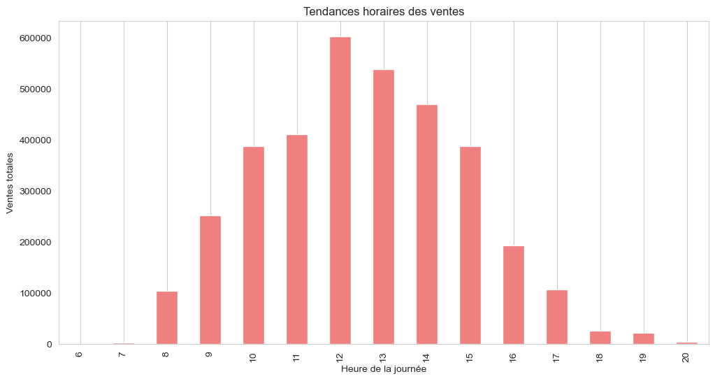

```python
# Extraction de l'heure de la colonne 'InvoiceDate'
ecommerce_data_cleaned['Hour'] = ecommerce_data_cleaned['InvoiceDate'].dt.hour

# Agrégation des données pour obtenir les ventes totales par heure
hourly_sales = ecommerce_data_cleaned.groupby('Hour')['TotalSales'].sum()

# Visualisation des ventes horaires
plt.figure(figsize=(12, 6))
hourly_sales.plot(kind='bar', color='lightcoral')
plt.title('Tendances horaires des ventes')
plt.xlabel('Heure de la journée')
plt.ylabel('Ventes totales')
plt.grid(axis='y')
plt.show()
```

La visualisation montre les tendances des ventes en fonction de l'heure de la journée.

```python
ecommerce_data_cleaned = ecommerce_data_cleaned.dropna(subset=['CustomerID'])
ecommerce_data_cleaned['TotalSpent'] = ecommerce_data_cleaned['Quantity'] * ecommerce_data_cleaned['UnitPrice']

grouped_data = ecommerce_data_cleaned.groupby('CustomerID').agg({
    'TotalSpent': 'sum',
    'InvoiceNo': 'nunique',
    'Quantity': 'mean',
    'InvoiceDate': 'mean'
})

grouped_data.columns = ['TotalSpent', 'NumberOfPurchases', 'AvgItemsPerPurchase', 'LastPurchaseDate']
grouped_data['DaysSinceLastPurchase'] = (pd.to_datetime('now') - pd.to_datetime(grouped_data['LastPurchaseDate'])).dt.days
grouped_data = grouped_data.drop('LastPurchaseDate', axis=1)


grouped_data.head()
```

| CustomerID | TotalSpent | NumberOfPurchases | AvgItemsPerPurchase | DaysSinceLastPurchase |
| --- | --- | --- | --- | --- |
| 12347.0 | 2257.63 | 7 | 11.709220 | 4536 |
| 12348.0 | 111.08 | 3 | 30.285714 | 4669 |
| 12349.0 | 1039.40 | 1 | 8.269841 | 4351 |
| 12350.0 | 294.40 | 1 | 12.250000 | 4642 |
| 12352.0 | 1247.94 | 7 | 6.986301 | 4482 |

```python
from sklearn.preprocessing import StandardScaler

# Initialisation du StandardScaler
scaler = StandardScaler()

# Normalisation des données
scaled_data = scaler.fit_transform(grouped_data)

# Conversion en DataFrame pour une meilleure lisibilité
scaled_data_df = pd.DataFrame(scaled_data, columns=grouped_data.columns, index=grouped_data.index)

scaled_data_df.head()
```

| CustomerID | TotalSpent | NumberOfPurchases | AvgItemsPerPurchase | DaysSinceLastPurchase |
| --- | --- | --- | --- | --- |
| 12347.0 | 0.805744 | 0.448899 | 0.276607 | 0.534648 |
| 12348.0 | -0.418919 | -0.135109 | 2.184205 | 1.999108 |
| 12349.0 | 0.110712 | -0.427113 | -0.076578 | -1.502382 |
| 12350.0 | -0.314330 | -0.427113 | 0.332139 | 1.701812 |
| 12352.0 | 0.229689 | 0.448899 | -0.208384 | -0.059944 |

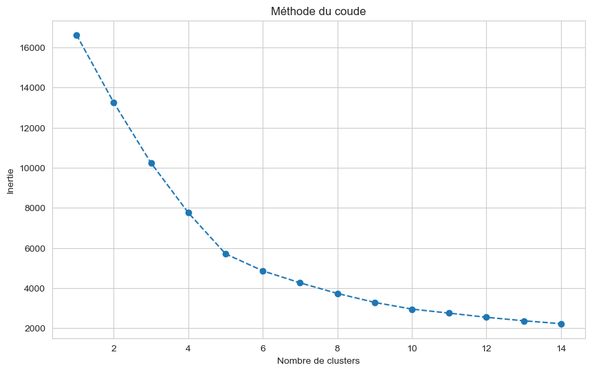

```python
from sklearn.cluster import KMeans

# Calcul de l'inertie pour différentes valeurs de K
inertia = []
range_values = range(1, 15)

for k in range_values:
    kmeans = KMeans(n_clusters=k, random_state=42)
    kmeans.fit(scaled_data)
    inertia.append(kmeans.inertia_)

# Tracé de la méthode du coude
plt.figure(figsize=(10,6))
plt.plot(range_values, inertia, marker='o', linestyle='--')
plt.title('Méthode du coude')
plt.xlabel('Nombre de clusters')
plt.ylabel('Inertie')
plt.grid(True)
plt.show()
```

```python
# Application de K-means avec K=5
kmeans = KMeans(n_clusters=5, random_state=42)
clusters = kmeans.fit_predict(scaled_data)
grouped_data['Cluster'] = clusters
```

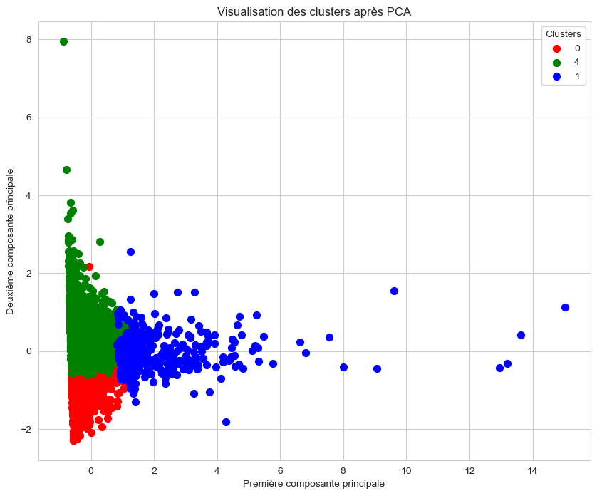

```python
from sklearn.decomposition import PCA

# Application de PCA
pca = PCA(n_components=2)
principal_components = pca.fit_transform(scaled_data)

# Création d'un DataFrame avec les deux composantes principales
pc_df = pd.DataFrame(data=principal_components, columns=['PC1', 'PC2'])
pc_df['Cluster'] = clusters

# Visualisation des clusters
plt.figure(figsize=(10, 8))
colors = ['r', 'g', 'b']

for cluster, color in zip(pc_df['Cluster'].unique(), colors):
    indices_to_keep = pc_df['Cluster'] == cluster
    plt.scatter(pc_df.loc[indices_to_keep, 'PC1'],
                pc_df.loc[indices_to_keep, 'PC2'],
                c=color, s=50)

plt.title('Visualisation des clusters après PCA')
plt.xlabel('Première composante principale')
plt.ylabel('Deuxième composante principale')
plt.legend(pc_df['Cluster'].unique(), title='Clusters')
plt.grid(True)
plt.show()
```

```python
grouped_data = ecommerce_data_cleaned.groupby('CustomerID').agg({
    'TotalSpent': 'sum',
    'InvoiceNo': 'nunique',
    'Quantity': 'mean',
    'InvoiceDate': 'max'
})

grouped_data.columns = ['TotalSpent', 'NumberOfPurchases', 'AvgItemsPerPurchase', 'LastPurchaseDate']
grouped_data['DaysSinceLastPurchase'] = (pd.to_datetime('now') - pd.to_datetime(grouped_data['LastPurchaseDate'])).dt.days
grouped_data = grouped_data.drop('LastPurchaseDate', axis=1)

grouped_data['Cluster'] = clusters

cluster_analysis = grouped_data.groupby('Cluster').mean()

cluster_analysis
```

| Cluster | TotalSpent | NumberOfPurchases | AvgItemsPerPurchase | DaysSinceLastPurchase |
| --- | --- | --- | --- | --- |
| 0 | 493.256298 | 2.617702 | 8.317786 | 4510.804771 |
| 1 | 3413.484490 | 15.033163 | 9.118596 | 4348.479592 |
| 2 | 41427.663333 | 170.000000 | 5.846473 | 4332.666667 |
| 3 | 20.000000 | 1.000000 | 500.000000 | 4416.000000 |
| 4 | 583.690472 | 2.648199 | 9.287835 | 4376.382733 |

Analysons les caractéristiques moyennes des clients pour chaque cluster basé sur les valeurs fournies :

- **Cluster 0** :
  - **Dépenses moyennes** : Les clients de ce cluster ont dépensé en moyenne environ 493 unités monétaires.
  - **Fréquence d'achat** : Ils ont effectué en moyenne 2.6 achats.
  - **Nombre moyen d'articles par achat** : Ils achètent en moyenne 8.3 articles par achat.
  - **Dernier achat** : Leur dernier achat remonte en moyenne à 4 510 jours (environ 12.3 années).
- **Cluster 1** :
  - **Dépenses moyennes** : Les clients de ce cluster ont dépensé en moyenne environ 3 413 unités monétaires.
  - **Fréquence d'achat** : Ils ont effectué en moyenne 15 achats.
  - **Nombre moyen d'articles par achat** : Ils achètent en moyenne 9.1 articles par achat.
  - **Dernier achat** : Leur dernier achat remonte en moyenne à 4 348 jours (environ 11.9 années).
- **Cluster 2** :
  - **Dépenses moyennes** : Les clients de ce cluster ont dépensé beaucoup plus, avec une moyenne d'environ 41 427 unités monétaires.
  - **Fréquence d'achat** : Ils ont effectué en moyenne 170 achats.
  - **Nombre moyen d'articles par achat** : Ils achètent en moyenne 5.8 articles par achat.
  - **Dernier achat** : Leur dernier achat remonte en moyenne à 4 332 jours (environ 11.9 années).
- **Cluster 3** :
  - **Dépenses moyennes** : Les clients de ce cluster ont dépensé 20 unités monétaires.
  - **Fréquence d'achat** : Ils ont effectué un seul achat.
  - **Nombre moyen d'articles par achat** : Ils ont acheté 500 articles lors de cet achat unique.
  - **Dernier achat** : Leur achat remonte à 4 416 jours (environ 12.1 années).
- **Cluster 4** :
  - **Dépenses moyennes** : Les clients de ce cluster ont dépensé en moyenne environ 584 unités monétaires.
  - **Fréquence d'achat** : Ils ont effectué en moyenne 2.6 achats.
  - **Nombre moyen d'articles par achat** : Ils achètent en moyenne 9.3 articles par achat.
  - **Dernier achat** : Leur dernier achat remonte en moyenne à 4 376 jours (environ 12 années).

### Interprétation :

- **Cluster 0 et Cluster 4** : Ces clients semblent être des acheteurs occasionnels avec des dépenses et une fréquence d'achat relativement faibles.
- **Cluster 1** : Ces clients dépensent plus que ceux des clusters 0 et 4 et achètent plus fréquemment. Ils pourraient être considérés comme des clients réguliers.
- **Cluster 2** : Il s'agit clairement de clients "VIP" ou de gros clients. Ils dépensent beaucoup plus que les autres clients et effectuent également un grand nombre d'achats.
- **Cluster 3** : Ce cluster est unique car les clients ont effectué un seul achat mais ont acheté une grande quantité d'articles lors de cet achat.

Ces segments peuvent être utilisés par une entreprise pour cibler différentes stratégies marketing ou de vente en fonction des caractéristiques et des comportements des clients. Par exemple, des offres spéciales pourraient être conçues pour les clients "VIP" du Cluster 2, tandis que des incitations pourraient être offertes aux clients des Clusters 0 et 4 pour augmenter leur fréquence d'achat.